# Redbubble Monthly Forecast

Tyson Klein

October 22, 2018

## R Markdown

RedBubble sales follow a gamma distribution (like any inter-arrival time or daily sales total), and can therefore be modelled with a Monte Carlo simulation. The benefit of a Monte Carlo simulation is that it can lend more information into current sales figures beyond just a mean or average daily sales figure.

The standard deviation of a daily sales figure is calculated as a weighted average of the Standard deviation of the following: 30% of the past 25 days + 30% of the past 15 days + 30% of the past 10 days + 10% of the past 5 days

And the mean sales figure per day is simply a 7% aplha adjusted mean (0.07*Daily Total + (1-0.07)*Previous Mean)

Using this model, the 95% confidence interval for the gamma distribution contains just over 94% of all data points.

A Monte Carlo simulation then can accurately show how ‘lucky’ the sales of each previous month actually was, and a rudimentary forecast can be made using the yearly trend of sales data (National Parks and RedBubble as a website).

The Mean and Standard Deviation of the data points ahead of today are calculated as:

mean = Mean of (Current Date - 365) * Yearly Growth Factor Standard Deviation = mean * Deviation Factor

The yearly growth factor is linear and constant (relatively) with an average value of 2.12 The deviation factor is the proportion of mean that Standard Deviation typically takes up, or about 0.55

```r
getwd()
```

```
## [1] "C:/Users/Tyson/Documents/R/projects/redbubble"
```

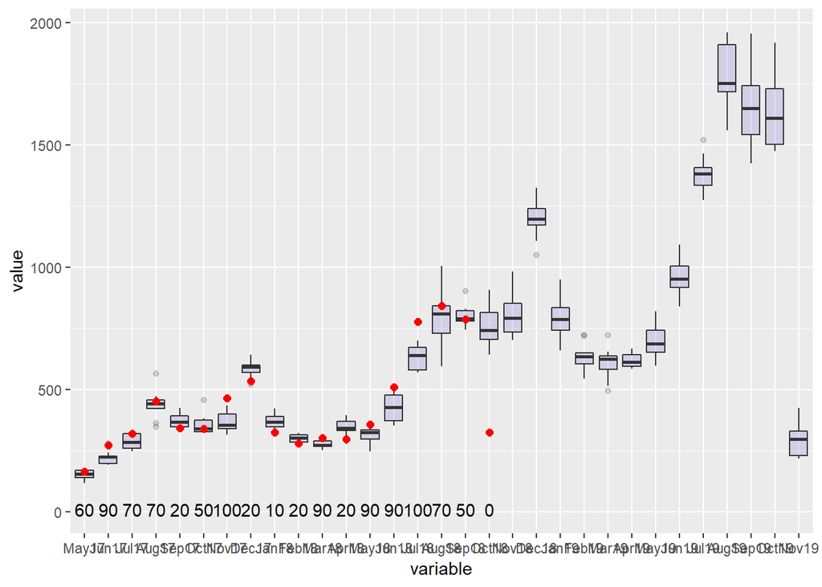

```r
load("rda/MC-boxPlot.rda")
MC.boxPlot
```